# HW8_training_arodriguezmu

ALVI RODRIGUEZ

INTRO TO DATA SCIENCE

12/4/2020

```r
#The packages I've used:
library(tidyverse)
library(GGally)
library(broom)
```

```r
nba <- read_csv("nba2k20-clean.csv")
head(nba)
```

A tibble: 6 × 14

| full_name <chr> | rating <dbl> | jersey <chr> | team <chr> | position <chr> | birth_year <dbl> | height <dbl> | weight <dbl> | salary <dbl> | country <chr> | draft_year <dbl> | draft_round <dbl> | draft_pick <dbl> | college <chr> |
| --- | --- | --- | --- | --- | --- | --- | --- | --- | --- | --- | --- | --- | --- |
| LeBron James | 97 | #23 | Los Angeles Lakers | F | 1984 | 2.06 | 250 | 37436858 | USA | 2003 | 1 | 1 | NA |
| Kawhi Leonard | 97 | #2 | Los Angeles Clippers | F | 1991 | 2.01 | 225 | 32742000 | USA | 2011 | 1 | 15 | San Diego State |
| Giannis Antetokounmpo | 96 | #34 | Milwaukee Bucks | SF | 1994 | 2.11 | 242 | 25842697 | Greece | 2013 | 1 | 15 | NA |
| Kevin Durant | 96 | #7 | Brooklyn Nets | F | 1988 | 2.08 | 230 | 37199000 | USA | 2007 | 1 | 2 | Texas |
| James Harden | 96 | #13 | Houston Rockets | G | 1989 | 1.96 | 220 | 38199000 | USA | 2009 | 1 | 3 | Arizona State |
| Stephen Curry | 95 | #30 | Golden State Warriors | G | 1988 | 1.91 | 185 | 40231758 | USA | 2009 | 1 | 7 | Davidson |

```r
#Here is the 60-40 train-test randomized split.
#For this assignment I'll be using nba_train
set.seed(42)

nba <- unite(nba, full_name, rating, col = 'name_rating', sep = '_', remove = FALSE)

name_rating <- nba %>% select(name_rating) %>% unique() %>% unlist(use.names = FALSE)

train_names <-  sample(name_rating, ceiling(length(name_rating) * 0.6))

train_nba <- nba %>% filter(name_rating %in% train_names)

glimpse(train_nba)

test_names <- setdiff(name_rating, train_names)

test_nba <- nba %>% filter(name_rating %in% test_names)

glimpse(test_nba)
```

```
Rows: 258
Columns: 15
$ name_rating <chr> "LeBron James_97", "Kawhi Leonard_97", "Giannis Antetok...
$ full_name   <chr> "LeBron James", "Kawhi Leonard", "Giannis Antetokounmpo...
$ rating      <dbl> 97, 97, 96, 96, 96, 95, 91, 90, 90, 89, 88, 88, 88, 87,...
$ jersey      <chr> "#23", "#2", "#34", "#7", "#13", "#30", "#21", "#15", "...
$ team        <chr> "Los Angeles Lakers", "Los Angeles Clippers", "Milwauke...
$ position    <chr> "F", "F", "SF", "F", "G", "G", "C", "C", "G", "G", "G",...
$ birth_year  <dbl> 1984, 1991, 1994, 1988, 1989, 1988, 1994, 1995, 1988, 1...
$ height      <dbl> 2.06, 2.01, 2.11, 2.08, 1.96, 1.91, 2.13, 2.13, 1.91, 1...
$ weight      <dbl> 250, 225, 242, 230, 220, 185, 250, 253, 190, 205, 220, ...
$ salary      <dbl> 37436858, 32742000, 25842697, 37199000, 38199000, 40231...
$ country     <chr> "USA", "USA", "Greece", "USA", "USA", "USA", "Cameroon"...
$ draft_year  <dbl> 2003, 2011, 2013, 2007, 2009, 2009, 2014, 2014, 2008, 2...
$ draft_round <chr> "1", "1", "1", "1", "1", "1", "1", "2", "1", "1", "1", ...
```

[output cut: 19 more lines]

```r
head(train_nba)
```

A tibble: 6 × 15

| name_rating <chr> | full_name <chr> | rating <dbl> | jersey <chr> | team <chr> | position <chr> | birth_year <dbl> | height <dbl> | weight <dbl> | salary <dbl> | country <chr> | draft_year <dbl> | draft_round <chr> | draft_pick <chr> | college <chr> |
| --- | --- | --- | --- | --- | --- | --- | --- | --- | --- | --- | --- | --- | --- | --- |
| LeBron James_97 | LeBron James | 97 | #23 | Los Angeles Lakers | F | 1984 | 2.06 | 250 | 37436858 | USA | 2003 | 1 | 1 | NA |
| Kawhi Leonard_97 | Kawhi Leonard | 97 | #2 | Los Angeles Clippers | F | 1991 | 2.01 | 225 | 32742000 | USA | 2011 | 1 | 15 | San Diego State |
| Giannis Antetokounmpo_96 | Giannis Antetokounmpo | 96 | #34 | Milwaukee Bucks | SF | 1994 | 2.11 | 242 | 25842697 | Greece | 2013 | 1 | 15 | NA |
| Kevin Durant_96 | Kevin Durant | 96 | #7 | Brooklyn Nets | F | 1988 | 2.08 | 230 | 37199000 | USA | 2007 | 1 | 2 | Texas |
| James Harden_96 | James Harden | 96 | #13 | Houston Rockets | G | 1989 | 1.96 | 220 | 38199000 | USA | 2009 | 1 | 3 | Arizona State |
| Stephen Curry_95 | Stephen Curry | 95 | #30 | Golden State Warriors | G | 1988 | 1.91 | 185 | 40231758 | USA | 2009 | 1 | 7 | Davidson |

### What is the relationship between height and salary in the nba?

It becomes more clear once we group all nba players by their heights. Evem though you wouldn't say there exists a positive linear correlation between height and salary in the NBA, we can see a trend. Taller players seem to get paid more than shorter players, meaning they are more valuable to a team. It seems hard to believe now that the NBA has become a league where its mostly threes, which you would think would benefit the shorter guys since they usually are better three point shooters. I believe if I had used data from 1995, we would have seen a positive relationship between height and salary, since back in the day, centers like Shaq, Olajuwon, Tim Duncan, David Robinson, etc, dominated the league and so were the highest paid players. The relation between weigh and salary, follows the same positive trend as heigh, which makes intuitive sense since taller players are heavier. However, the slope of the linear regression is not as steep. I believe this is because since the game now is not as physical, we are seeing a lot of superstars like Kevin Durant, Kristaps Porzingis, Brandom Ingram, etc, that are very tall but really skinny and have developed their game into perimeter players and have become really good shooters.

```r
summary_nba_height <- train_nba %>%
    group_by(height) %>%
    summarize(avg_salary = mean(salary, na.rm = TRUE)) %>%
    na.omit() %>%
    ungroup()
```

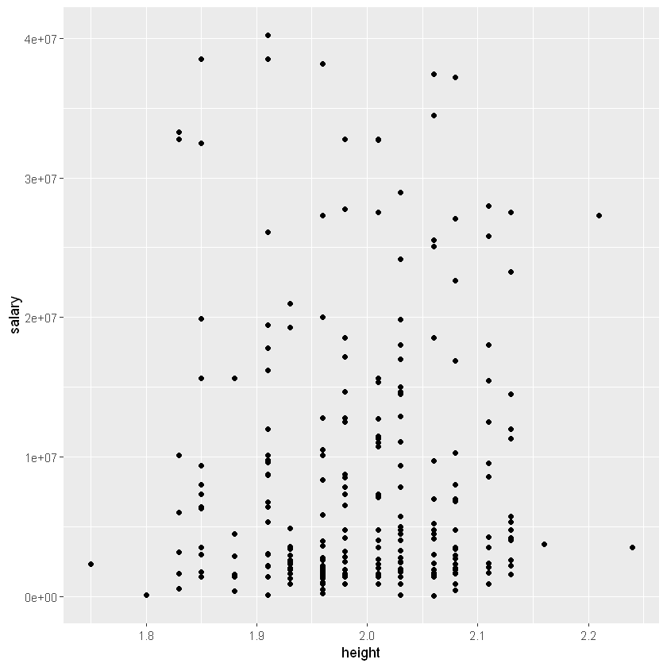

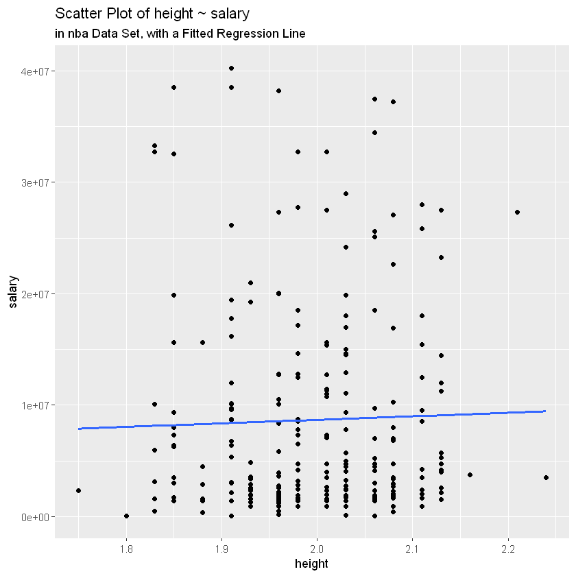

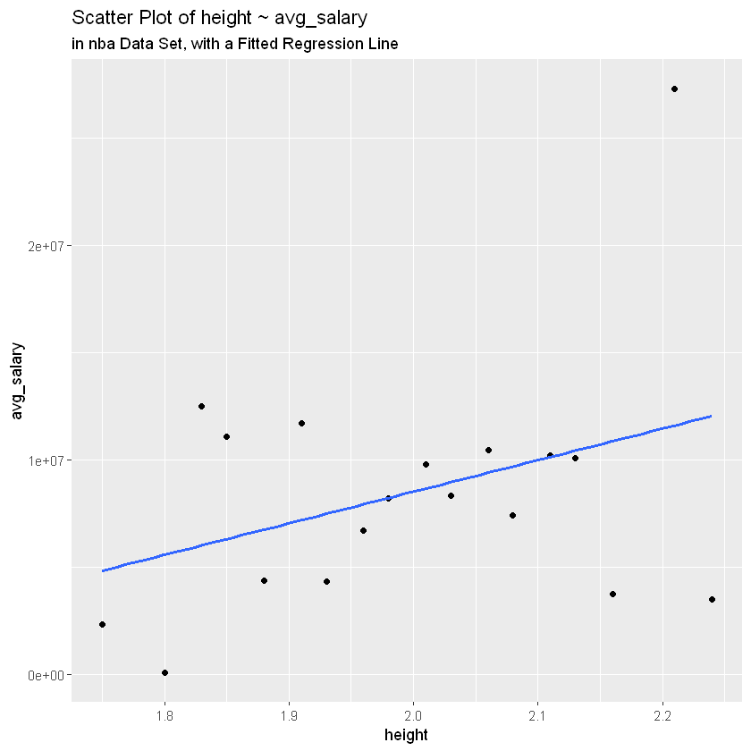

```r
#Height is in meters, therefore 1.8m = 6', 1.9m = 6'3'', 2m = 6'6'', 2.10m = 6'10'', 2.2m = 7'2''
ggplot(train_nba, aes(height, salary), na.rm = TRUE) +
    geom_point()

train_nba %>% ggplot(aes(x = height, y = salary), na.rm = TRUE) +
    geom_point() +
    geom_smooth(method = 'lm', formula = y ~ x, se = FALSE, na.rm = TRUE) +
    labs(title = 'Scatter Plot of height ~ salary',
         subtitle = 'in nba Data Set, with a Fitted Regression Line')

summary_nba_height %>% ggplot(aes(x = height, y = avg_salary), na.rm = TRUE) +
    geom_point() +
    geom_smooth(method = 'lm', formula = y ~ x, se = FALSE, na.rm = TRUE) +
    labs(title = 'Scatter Plot of height ~ avg_salary',
         subtitle = 'in nba Data Set, with a Fitted Regression Line')
```

```r
summary_nba_weight <- train_nba %>%
    group_by(weight) %>%
    summarize(avg_salary = mean(salary, na.rm = TRUE)) %>%
    na.omit() %>%
    ungroup()
head(summary_nba_weight)
```

A tibble: 6 × 2

| weight <dbl> | avg_salary <dbl> |
| --- | --- |
| 170 | 1893148 |
| 171 | 6392760 |
| 172 | 32742000 |
| 174 | 8730240 |
| 175 | 12212070 |
| 178 | 3150000 |

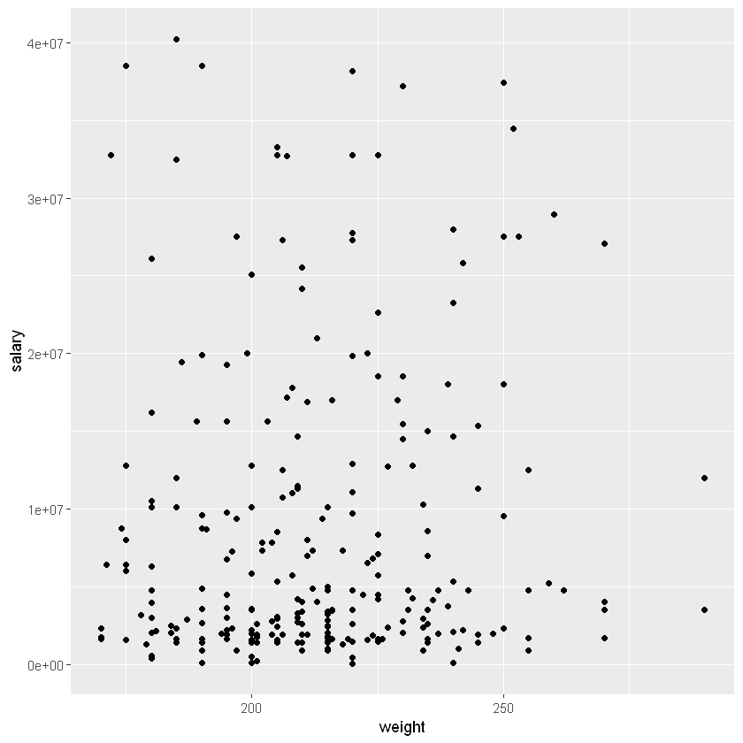

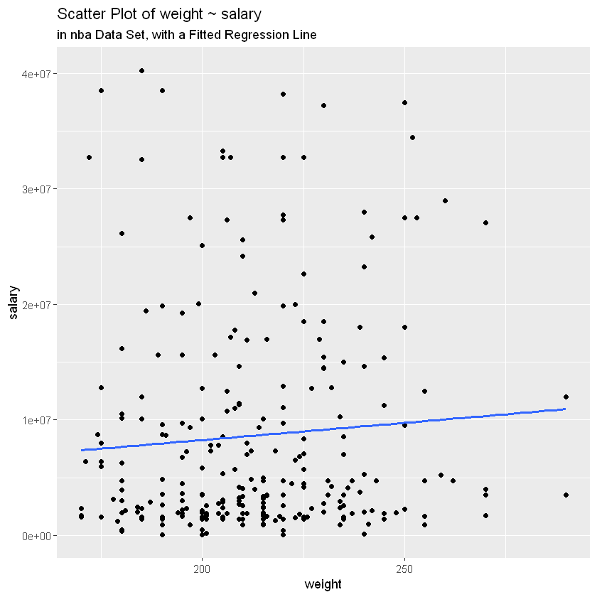

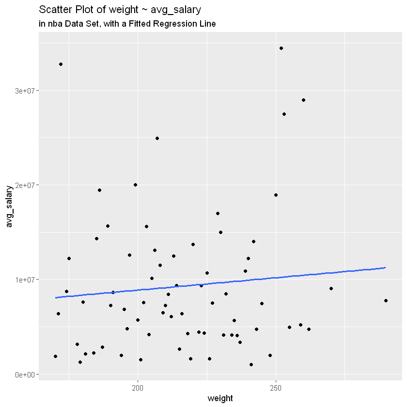

```r
ggplot(train_nba, aes(weight, salary)) +
    geom_point()

train_nba %>% ggplot(aes(x = weight, y = salary)) +
    geom_point() +
    geom_smooth(method = 'lm', formula = y ~ x, se = FALSE) +
    labs(title = 'Scatter Plot of weight ~ salary',
         subtitle = 'in nba Data Set, with a Fitted Regression Line')

summary_nba_weight %>% ggplot(aes(x = weight, y = avg_salary)) +
    geom_point() +
    geom_smooth(method = 'lm', formula = y ~ x, se = FALSE) +
    labs(title = 'Scatter Plot of weight ~ avg_salary',
         subtitle = 'in nba Data Set, with a Fitted Regression Line')
```

### Do younger players get paid more money than older players? or does the NBA reward veteran players?

```r
summary_nba_age <- train_nba %>%
    group_by(birth_year) %>%
    summarize(avg_salary = mean(salary, na.rm = TRUE)) %>%
    na.omit() %>%
    ungroup()
head(summary_nba_age)
```

A tibble: 6 × 2

| birth_year <dbl> | avg_salary <dbl> |
| --- | --- |
| 1982 | 2564753 |
| 1984 | 27311022 |
| 1985 | 19871730 |
| 1986 | 12420511 |
| 1987 | 16189943 |
| 1988 | 18228157 |

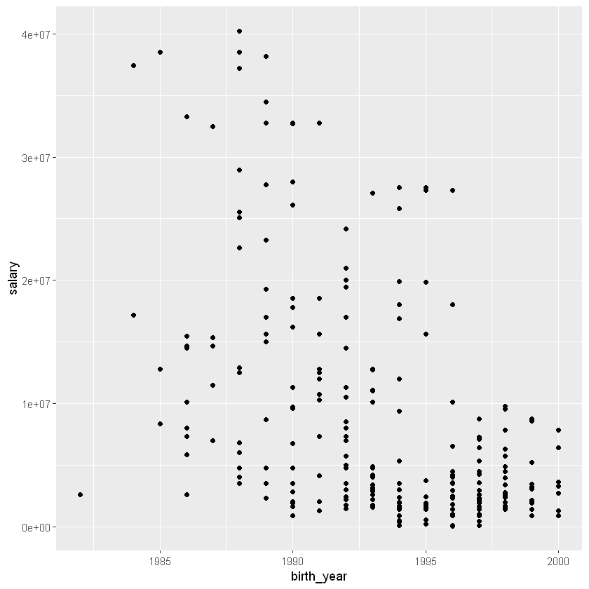

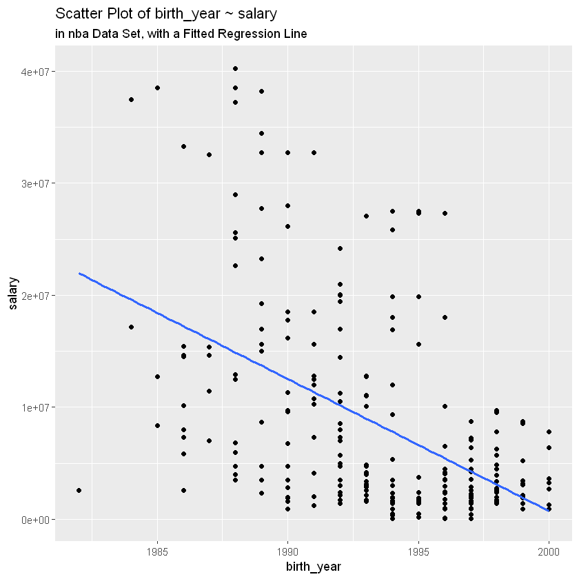

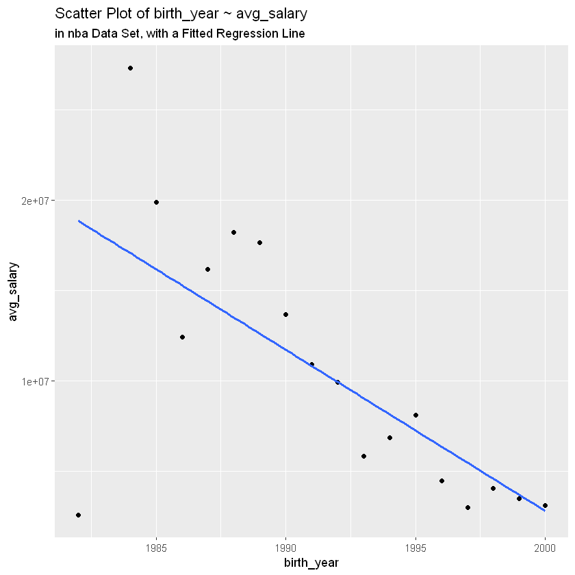

```r
ggplot(train_nba, aes(birth_year, salary)) +
    geom_point()

train_nba %>% ggplot(aes(x = birth_year, y = salary)) +
    geom_point() +
    geom_smooth(method = 'lm', formula = y ~ x, se = FALSE) +
    labs(title = 'Scatter Plot of birth_year ~ salary',
         subtitle = 'in nba Data Set, with a Fitted Regression Line')

summary_nba_age %>% ggplot(aes(x = birth_year, y = avg_salary)) +
    geom_point() +
    geom_smooth(method = 'lm', formula = y ~ x, se = FALSE) +
    labs(title = 'Scatter Plot of birth_year ~ avg_salary',
         subtitle = 'in nba Data Set, with a Fitted Regression Line')
```

A tibble: 6 × 5

| birth_year <dbl> | avg_salary <dbl> | height <dbl> | weight <dbl> | draft_round <chr> |
| --- | --- | --- | --- | --- |
| 1982 | 2564753 | 2.13 | 235 | 1 |
| 1984 | 27311022 | 2.06 | 250 | 1 |
| 1984 | 27311022 | 1.98 | 207 | 1 |
| 1985 | 19871730 | 1.85 | 175 | 1 |
| 1985 | 19871730 | 1.96 | 225 | 2 |
| 1985 | 19871730 | 1.96 | 200 | 1 |

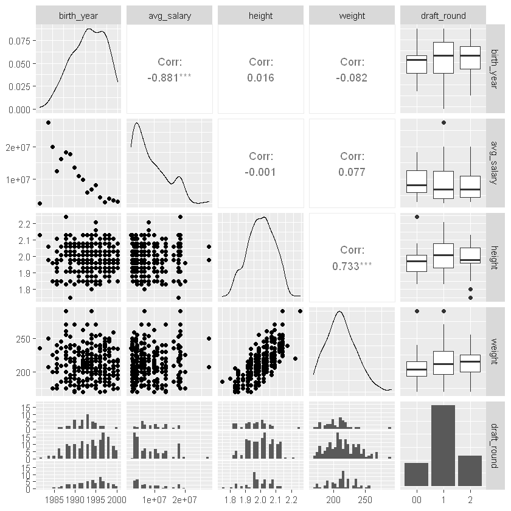

```r
summary_nba <- train_nba %>%
    group_by(birth_year) %>%
    summarize(avg_salary = mean(salary, na.rm = TRUE),
              height,
              weight,
              draft_round) %>%
    na.omit() %>%
    ungroup()
head(summary_nba)

ggpairs(summary_nba, upper = list(continuous = wrap('cor', family = 'sans')))
```

### Multiple Regression Model

Let's run a multiple regression, in which avg_salary is the dependent variable, and height, weight, and birth_year are the independent variables.

tidy() produces a tibble in which we see relevant information about my model. Something that caught my attention are the p-values. The p-values for height and weight, 0.66 and 0.83 respectively, are pretty high which indicates that my evidence is not strong enough to suggest that an significant effect exists between salary and height and weight. However, the p-value for birth_year is almost 0 which tells us there exists a clear relationship between salary and birth_year.

glance() report information about the entire model. I was able to show how well does the model fit the observed data. It turns out that it fits the model very well. Both the r.squared and the adj.r.squared have a value of >.7 .

augment() adds information about observations to my dataset which includes predicted values in the .fitted column, residuals in the .resid column, and standardized residual values in the .std.resid column. In the .fitted column, we see the values that are calculated after the best model that fits the data. Therefore we would want the .fitted columnn to be as close as the dependent variablee(salary), or in other words, we would want for the values in the .resid column to be as low as possible which would mean that our model is pretty close to the best model that fits the data possible.

```r
nba_mod1 <- summary_nba %>%
    lm(avg_salary ~ height + weight + birth_year, data = .)

tidy(nba_mod1)


glance(nba_mod1)

augment(nba_mod1)  %>% head()
```

A tibble: 4 × 5

| term <chr> | estimate <dbl> | std.error <dbl> | statistic <dbl> | p.value <dbl> |
| --- | --- | --- | --- | --- |
| (Intercept) | 2.358599e+09 | 79982399.43 | 29.4889809 | 7.873870e-84 |
| height | 1.226363e+06 | 2750721.88 | 0.4458333 | 6.560990e-01 |
| weight | -2.170605e+03 | 10028.99 | -0.2164331 | 8.288246e-01 |
| birth_year | -1.179924e+06 | 40232.42 | -29.3276803 | 2.306649e-83 |

A tibble: 1 × 12

| r.squared <dbl> | adj.r.squared <dbl> | sigma <dbl> | statistic <dbl> | p.value <dbl> | df <dbl> | logLik <dbl> | AIC <dbl> | BIC <dbl> | deviance <dbl> | df.residual <int> | nobs <int> |
| --- | --- | --- | --- | --- | --- | --- | --- | --- | --- | --- | --- |
| 0.7757032 | 0.7730435 | 2509003 | 291.6566 | 8.496623e-82 | 3 | -4149.648 | 8309.296 | 8327.042 | 1.592659e+15 | 253 | 257 |

A tibble: 6 × 10

| avg_salary <dbl> | height <dbl> | weight <dbl> | birth_year <dbl> | .fitted <dbl> | .resid <dbl> | .std.resid <dbl> | .hat <dbl> | .sigma <dbl> | .cooksd <dbl> |
| --- | --- | --- | --- | --- | --- | --- | --- | --- | --- |
| 2564753 | 2.13 | 235 | 1982 | 22092760 | -19528007 | -7.9802631 | 0.04878412 | 2174673 | 0.816533207 |
| 27311022 | 2.06 | 250 | 1984 | 19614508 | 7696513 | 3.1208668 | 0.03387072 | 2465111 | 0.085364955 |
| 27311022 | 1.98 | 207 | 1984 | 19609735 | 7701286 | 3.1113996 | 0.02677640 | 2465410 | 0.066587269 |
| 19871730 | 1.85 | 175 | 1985 | 18339844 | 1531887 | 0.6215605 | 0.03509578 | 2512056 | 0.003512995 |
| 19871730 | 1.96 | 225 | 1985 | 18366213 | 1505517 | 0.6077421 | 0.02516658 | 2512140 | 0.002383814 |
| 19871730 | 1.96 | 200 | 1985 | 18420478 | 1451252 | 0.5853484 | 0.02354006 | 2512273 | 0.002065009 |